# Практика 36 · Друга спадна гілка (подвійний спуск)

> 📖 **Теорія:** відкрий `lecture.html` у цій же теці. 📝 **Домашнє завдання:** `homework.md` · 🧪 **Тест:** `quiz.html`

У лекції ти рухав повзунки й бачив криву подвійного спуску. Тут ми зберемо той самий стенд руками, на чистому NumPy, і перевіримо кожне твердження числом.

**Що зробимо:**

1. Зберемо модель із випадкових нелінійних ознак — таку саму, як в інтерактивах лекції
2. Навчимо її методом найменших квадратів і розвʼязком мінімальної норми (`np.linalg.pinv`)
3. Звіримо нашу підгонку зі `scikit-learn` — має збігтися до 10⁻⁸
4. Побудуємо криву тестової помилки з піком **рівно на p = N**
5. Побудуємо норму коефіцієнтів і побачимо ту саму форму
6. Покажемо, що явний L2-штраф (Ridge) пік прибирає
7. Перевіримо, чи винен у піку шум

## 1. Стенд: дані

Беремо рівно те, що в лекції: гладка істинна функція, 24 навчальні точки з шумом і **300 тестових точок**. Тестова вибірка велика навмисно — на маленькій крива помилки шумить так, що піку не видно.

```python
import numpy as np
import matplotlib.pyplot as plt

КІЛЬКІСТЬ_НАВЧАЛЬНИХ = 24     # це і є N — воно ж поріг інтерполяції
КІЛЬКІСТЬ_ТЕСТОВИХ = 300      # велика вибірка: інакше оцінка помилки скаче
РІВЕНЬ_ШУМУ = 0.12


def істинна_функція(x):
    """Те, що модель має відновити. У даних її ніхто не бачить — лише зашумлені значення."""
    return np.sin(3.4 * x) + 0.4 * x


rng = np.random.default_rng(42)

# навчальні точки майже рівномірні, з дрібним зсувом — щоб сітка не була ідеальною
x_train = np.linspace(-1, 1, КІЛЬКІСТЬ_НАВЧАЛЬНИХ, endpoint=False)
x_train = x_train + 1 / КІЛЬКІСТЬ_НАВЧАЛЬНИХ + rng.uniform(-0.025, 0.025, КІЛЬКІСТЬ_НАВЧАЛЬНИХ)
x_test = np.sort(rng.uniform(-1, 1, КІЛЬКІСТЬ_ТЕСТОВИХ))

# шум зберігаємо окремо від сигналу: далі ми будемо крутити його рівень
шум_train = rng.normal(0, 1, КІЛЬКІСТЬ_НАВЧАЛЬНИХ)
шум_test = rng.normal(0, 1, КІЛЬКІСТЬ_ТЕСТОВИХ)

y_train = істинна_функція(x_train) + РІВЕНЬ_ШУМУ * шум_train
y_test = істинна_функція(x_test) + РІВЕНЬ_ШУМУ * шум_test

print(f"навчальних точок N = {КІЛЬКІСТЬ_НАВЧАЛЬНИХ}, тестових = {КІЛЬКІСТЬ_ТЕСТОВИХ}")
print(f"рівень шуму σ = {РІВЕНЬ_ШУМУ}")
print(f"x від {x_train.min():.2f} до {x_train.max():.2f}, y від {y_train.min():.2f} до {y_train.max():.2f}")
```

```
навчальних точок N = 24, тестових = 300
рівень шуму σ = 0.12
x від -0.94 до 0.98, y від -1.27 до 1.35
```

## 2. Стенд: випадкові нелінійні ознаки

Модель із лекції влаштована так: беремо `p` **випадкових гладких хвилястих функцій** φ₁(x) … φ_p(x) і вчимо поверх них звичайну лінійну модель

f(x) = γ₁·φ₁(x) + γ₂·φ₂(x) + … + γ_p·φ_p(x)

Самі ознаки не навчаються — вони кинуті раз і назавжди. Навчаються лише ваги γ. Це рівно те, чим є нейромережа з одним випадковим прихованим шаром і навченим виходом.

Кожна ознака — випадкова суміш 50 косинусів, причому високі частоти беруться з меншою амплітудою. Тому ознаки в середньому гладкі, але всі різні.

```python
КІЛЬКІСТЬ_КОСИНУСІВ = 50
СПАД_АМПЛІТУДИ = 1.2          # чим більший, тим гладші ознаки
МАКС_ПАРАМЕТРІВ = 200
КІЛЬКІСТЬ_ЖЕРЕБІВ = 15        # скільки разів перекидаємо набір ознак

# амплітуда j-го косинуса: високі частоти пригнічені
амплітуди = (1.0 + np.arange(КІЛЬКІСТЬ_КОСИНУСІВ)) ** (-СПАД_АМПЛІТУДИ)


def косинусний_базис(x):
    """Матриця значень cos(j·π·(x+1)/2) для всіх точок x і всіх j. Розмір: len(x) × 50."""
    номери = np.arange(КІЛЬКІСТЬ_КОСИНУСІВ)
    return np.cos(np.outer(np.asarray(x, dtype=float) + 1.0, номери) * np.pi / 2.0)


def випадкові_ознаки(номер_жереба):
    """Матриця 50 × 200: кожен стовпець — коефіцієнти однієї випадкової ознаки."""
    r = np.random.default_rng(1000 + номер_жереба)
    суміш = r.normal(size=(КІЛЬКІСТЬ_КОСИНУСІВ, МАКС_ПАРАМЕТРІВ))
    return суміш * амплітуди[:, None]     # гасимо високі частоти


базис_train = косинусний_базис(x_train)
базис_test = косинусний_базис(x_test)
ЖЕРЕБИ = [випадкові_ознаки(s) for s in range(КІЛЬКІСТЬ_ЖЕРЕБІВ)]

print(f"базис на навчальних точках: {базис_train.shape}")
print(f"один жереб ознак: {ЖЕРЕБИ[0].shape}  (50 косинусів × 200 ознак)")
print(f"усього жеребів: {len(ЖЕРЕБИ)} — по них далі беремо медіану")
```

```
базис на навчальних точках: (24, 50)
один жереб ознак: (50, 200)  (50 косинусів × 200 ознак)
усього жеребів: 15 — по них далі беремо медіану
```

### Як виглядають самі ознаки

Подивимось на перші три ознаки одного жеребу. Це просто хвилясті криві — жодної структури, повʼязаної з нашою задачею, у них немає.

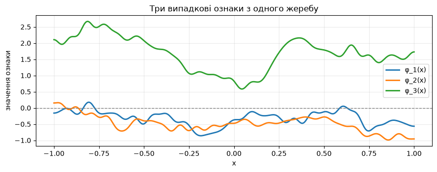

```
Ознаки гладкі, але між собою некорельовані за задумом — і саме з них
модель мусить скласти істинну криву.
```

```python
сітка = np.linspace(-1, 1, 400)
базис_сітки = косинусний_базис(сітка)

fig, ax = plt.subplots(figsize=(9, 3.6))
for номер in range(3):
    значення_ознаки = базис_сітки @ ЖЕРЕБИ[0][:, номер]
    ax.plot(сітка, значення_ознаки, lw=2, label=f"φ_{номер + 1}(x)")
ax.axhline(0, color="gray", lw=1, ls="--")
ax.set_xlabel("x"); ax.set_ylabel("значення ознаки")
ax.set_title("Три випадкові ознаки з одного жеребу")
ax.legend(); ax.grid(alpha=.25)
plt.tight_layout(); plt.show()

print("Ознаки гладкі, але між собою некорельовані за задумом — і саме з них")
print("модель мусить скласти істинну криву.")
```

## 3. Правило підгонки

Тут ховається вся суть теми, тому проговоримо повільно.

- Поки **p ≤ N** (параметрів не більше, ніж точок), рівнянь не менше, ніж невідомих. Точно пройти крізь усі точки зазвичай неможливо, тому шукаємо компроміс — звичайний МНК.
- Коли **p > N**, невідомих більше, ніж рівнянь. Розвʼязків, які проходять крізь **усі** навчальні точки, стає нескінченно багато. Дані вже нічого не вибирають — вибирає алгоритм. Ми беремо той інтерполянт, у якого **найменша норма ‖γ‖**.

Приємна новина: обидва випадки закриває одна функція — псевдообернена матриця `np.linalg.pinv`. При p ≤ N вона дає розвʼязок МНК, при p > N — розвʼязок мінімальної норми. Це не збіг, а означення псевдооберненої.

```python
def навчити(матриця_плану, y, штраф=0.0):
    """Ваги моделі. При штраф=0 — МНК або мінімальна норма (залежно від форми матриці).

    Явно рахувати норму й порівнювати p з N не треба: pinv робить рівно те,
    що нам потрібно, в обох режимах.
    """
    if штраф > 0:
        # гребенева регресія (Ridge): додаємо λ·I до нормального рівняння
        кількість_параметрів = матриця_плану.shape[1]
        ліва = матриця_плану.T @ матриця_плану + штраф * np.eye(кількість_параметрів)
        return np.linalg.solve(ліва, матриця_плану.T @ y)
    return np.linalg.pinv(матриця_плану) @ y


def матриця_плану(номер_жереба, p, базис):
    """Значення перших p ознак жеребу в усіх точках. Розмір: точок × p."""
    return базис @ ЖЕРЕБИ[номер_жереба][:, :p]


# швидка перевірка обох режимів
for p in [10, 24, 60]:
    план = матриця_плану(0, p, базис_train)
    ваги = навчити(план, y_train)
    залишок = np.max(np.abs(y_train - план @ ваги))
    режим = "класичний" if p < 24 else ("поріг" if p == 24 else "надпараметризований")
    print(f"p={p:3d}  {режим:20s}  макс. залишок на навчанні = {залишок:.2e}  ‖γ‖={np.linalg.norm(ваги):8.2f}")
```

```
p= 10  класичний             макс. залишок на навчанні = 4.47e-01  ‖γ‖=    2.18
p= 24  поріг                 макс. залишок на навчанні = 6.00e-15  ‖γ‖=    3.20
p= 60  надпараметризований   макс. залишок на навчанні = 8.22e-15  ‖γ‖=    0.83
```

### Чому саме мінімальна норма

Перевіримо, що `pinv` при p > N справді дає **найкоротший** з усіх інтерполянтів. Візьмемо розвʼязок `pinv`, зсунемо його вздовж напрямку, який не змінює жодного значення в навчальних точках (тобто вздовж ядра матриці плану), — і подивимось на норму.

```python
p_багато = 60
план = матриця_плану(0, p_багато, базис_train)
ваги_мін = навчити(план, y_train)

# ядро матриці плану: напрямки, уздовж яких прогнози на навчальних точках не змінюються
_, сингулярні, права_матриця = np.linalg.svd(план)
ядро = права_матриця[len(сингулярні):]      # рядки, що відповідають нульовим сингулярним числам

r = np.random.default_rng(5)
print(f"розмірність множини інтерполянтів: {ядро.shape[0]}  (= p − N = {p_багато} − 24)")
print(f"\n{'варіант':>22} {'‖γ‖':>10} {'макс. залишок':>16}")
print(f"{'мінімальна норма':>22} {np.linalg.norm(ваги_мін):10.3f} {np.max(np.abs(y_train - план @ ваги_мін)):16.2e}")

for спроба in range(4):
    зсув = r.normal(size=ядро.shape[0]) @ ядро      # рух усередині множини інтерполянтів
    інший = ваги_мін + зсув
    print(f"{'інший інтерполянт':>22} {np.linalg.norm(інший):10.3f} "
          f"{np.max(np.abs(y_train - план @ інший)):16.2e}")

assert np.linalg.norm(ваги_мін) < np.linalg.norm(ваги_мін + r.normal(size=ядро.shape[0]) @ ядро)
print("\n✅ розвʼязок pinv справді найкоротший, а залишки в усіх варіантів нульові")
```

```
розмірність множини інтерполянтів: 36  (= p − N = 60 − 24)

               варіант        ‖γ‖    макс. залишок
      мінімальна норма      0.829         8.22e-15
     інший інтерполянт      5.261         8.33e-15
     інший інтерполянт      5.854         1.28e-14
     інший інтерполянт      5.508         1.09e-14
     інший інтерполянт      5.193         7.99e-15

✅ розвʼязок pinv справді найкоротший, а залишки в усіх варіантів нульові
```

## 4. Звірка зі scikit-learn

Обовʼязковий крок: переконатись, що всередині бібліотеки немає магії. У класичному режимі (p < N) наша функція має дати рівно те саме, що `LinearRegression`.

```python
from sklearn.linear_model import LinearRegression

p_класичний = 12
план = матриця_плану(0, p_класичний, базис_train)
наші_ваги = навчити(план, y_train)

# fit_intercept=False, бо вільний член у нас не передбачений — модель це чиста сума ознак
модель_sklearn = LinearRegression(fit_intercept=False).fit(план, y_train)

print(f"наші ваги   (перші 4): {np.round(наші_ваги[:4], 6)}")
print(f"sklearn     (перші 4): {np.round(модель_sklearn.coef_[:4], 6)}")
print(f"макс. різниця: {np.max(np.abs(наші_ваги - модель_sklearn.coef_)):.2e}")

assert np.allclose(наші_ваги, модель_sklearn.coef_), "розрахунок розійшовся!"
print("\n✅ збігається")
```

```
наші ваги   (перші 4): [ 1.188524 -0.432319 -0.135792 -0.952564]
sklearn     (перші 4): [ 1.188524 -0.432319 -0.135792 -0.952564]
макс. різниця: 4.44e-15

✅ збігається
```

## 5. Головна крива

Тепер будуємо те, заради чого все затівалось: тестову помилку як функцію кількості параметрів. Помилку міряємо через MAE (середнє абсолютне відхилення) і **усереднюємо медіаною по 15 жеребах ознак** — інакше крива стрибала б від одного невдалого розкладу.

Сітка по p згущена біля порогу p = N = 24: саме там уся драма.

```python
СІТКА_P = list(range(1, 9)) + list(range(10, 33, 2)) + [36, 44, 54, 66, 82, 100, 124, 155, 200]


def побудувати_криву(сітка_p, рівень_шуму=РІВЕНЬ_ШУМУ, штраф=0.0):
    """Для кожного p: медіанна тестова MAE, навчальна MAE і норма ваг по всіх жеребах."""
    y_навч = істинна_функція(x_train) + рівень_шуму * шум_train
    y_тест = істинна_функція(x_test) + рівень_шуму * шум_test

    тестова, навчальна, норми = [], [], []
    for p in сітка_p:
        по_жеребах_тест, по_жеребах_навч, по_жеребах_норма = [], [], []
        for жереб in range(КІЛЬКІСТЬ_ЖЕРЕБІВ):
            план_навч = матриця_плану(жереб, p, базис_train)
            ваги = навчити(план_навч, y_навч, штраф)
            прогноз_тест = матриця_плану(жереб, p, базис_test) @ ваги
            по_жеребах_тест.append(np.mean(np.abs(y_тест - прогноз_тест)))
            по_жеребах_навч.append(np.mean(np.abs(y_навч - план_навч @ ваги)))
            по_жеребах_норма.append(np.linalg.norm(ваги))
        тестова.append(np.median(по_жеребах_тест))
        навчальна.append(np.median(по_жеребах_навч))
        норми.append(np.median(по_жеребах_норма))
    return np.array(тестова), np.array(навчальна), np.array(норми)


тест_mae, навч_mae, норма_ваг = побудувати_криву(СІТКА_P)

print(f"{'p':>5} {'test MAE':>11} {'train MAE':>11} {'‖γ‖':>10}   режим")
for k, p in enumerate(СІТКА_P):
    if p in (1, 8, 16, 22, 24, 26, 32, 54, 100, 200):
        режим = "класичний" if p < 24 else ("← ПОРІГ p = N" if p == 24 else "надпараметризований")
        print(f"{p:>5} {тест_mae[k]:11.4f} {навч_mae[k]:11.4f} {норма_ваг[k]:10.2f}   {режим}")
```

```
    p    test MAE   train MAE        ‖γ‖   режим
    1      0.7611      0.7398       0.19   класичний
    8      0.2342      0.2092       1.68   класичний
   16      0.1703      0.0993       1.93   класичний
   22      0.2265      0.0463       3.89   класичний
   24      0.8311      0.0000      18.01   ← ПОРІГ p = N
   26      0.2534      0.0000       3.90   надпараметризований
   32      0.1591      0.0000       1.98   надпараметризований
   54      0.1346      0.0000       1.01   надпараметризований
  100      0.1294      0.0000       0.66   надпараметризований
  200      0.1273      0.0000       0.43   надпараметризований
```

### Перевірка головного твердження

Пік тестової помилки має стояти **рівно на p = N**, а не «десь поруч». Це не фігура мовлення — це те, що можна перевірити `assert`-ом.

```python
індекс_порогу = СІТКА_P.index(КІЛЬКІСТЬ_НАВЧАЛЬНИХ)
індекс_піку = int(np.argmax(тест_mae))

# найкраща класична модель: беремо з безпечної відстані від порогу
маска_класична = np.array(СІТКА_P) <= КІЛЬКІСТЬ_НАВЧАЛЬНИХ - 4
маска_далеко = np.array(СІТКА_P) >= 2 * КІЛЬКІСТЬ_НАВЧАЛЬНИХ
класичний_мінімум = тест_mae[маска_класична].min()
дно_другого_спуску = тест_mae[маска_далеко].min()

print(f"пік тестової помилки  : p = {СІТКА_P[індекс_піку]},  MAE = {тест_mae[індекс_піку]:.4f}")
print(f"кращий класичний      : MAE = {класичний_мінімум:.4f}")
print(f"дно другого спуску    : MAE = {дно_другого_спуску:.4f}")
print(f"\nпік гірший за класику у {тест_mae[індекс_піку] / класичний_мінімум:.1f} раза")
print(f"друга гілка краща за класику у {класичний_мінімум / дно_другого_спуску:.2f} раза")

assert СІТКА_P[індекс_піку] == КІЛЬКІСТЬ_НАВЧАЛЬНИХ, "пік стоїть не на порозі інтерполяції!"
assert дно_другого_спуску < класичний_мінімум, "друга гілка не опустилась нижче класичної!"
print("\n✅ пік рівно на p = N, і друга гілка опустилась нижче класичного мінімуму")
```

```
пік тестової помилки  : p = 24,  MAE = 0.8311
кращий класичний      : MAE = 0.1703
дно другого спуску    : MAE = 0.1273

пік гірший за класику у 4.9 раза
друга гілка краща за класику у 1.34 раза

✅ пік рівно на p = N, і друга гілка опустилась нижче класичного мінімуму
```

### Малюємо криву

Обидві осі логарифмічні — інакше пік розчавить усе решту.

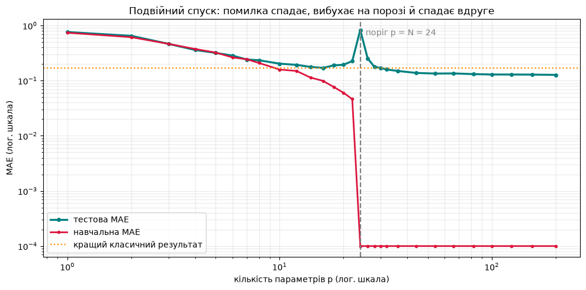

```
Ліворуч від пунктиру — знайома U-крива з підручника.
На пунктирі — вузький пік. Праворуч — навчальна помилка вже нульова,
а тестова спокійно опускається нижче за все, чого досягала класична модель.
```

```python
fig, ax = plt.subplots(figsize=(10, 5))

ax.plot(СІТКА_P, тест_mae, color="teal", lw=2.4, marker="o", ms=4, label="тестова MAE")
# нульову навчальну помилку на лог-шкалі не намалюєш — підмінюємо крихітним числом
навчальна_для_графіка = np.maximum(навч_mae, 1e-4)
ax.plot(СІТКА_P, навчальна_для_графіка, color="crimson", lw=2, marker="o", ms=3,
        label="навчальна MAE")
ax.axvline(КІЛЬКІСТЬ_НАВЧАЛЬНИХ, color="gray", ls="--", lw=1.6)
ax.axhline(класичний_мінімум, color="darkorange", ls=":", lw=1.6,
           label="кращий класичний результат")
ax.text(КІЛЬКІСТЬ_НАВЧАЛЬНИХ * 1.06, тест_mae.max() * 0.8, "поріг p = N = 24",
        color="gray", fontsize=10)

ax.set_xscale("log"); ax.set_yscale("log")
ax.set_xlabel("кількість параметрів p (лог. шкала)")
ax.set_ylabel("MAE (лог. шкала)")
ax.set_title("Подвійний спуск: помилка спадає, вибухає на порозі й спадає вдруге")
ax.legend(); ax.grid(alpha=.25, which="both")
plt.tight_layout(); plt.show()

print("Ліворуч від пунктиру — знайома U-крива з підручника.")
print("На пунктирі — вузький пік. Праворуч — навчальна помилка вже нульова,")
print("а тестова спокійно опускається нижче за все, чого досягала класична модель.")
```

## 6. Як виглядає підгонка в кожному режимі

Числа — це добре, але корисніше побачити самі криві. Візьмемо чотири моделі: недонавчену (p=6), майже оптимальну класичну (p=16), рівно на порозі (p=24) і глибоко надпараметризовану (p=200).

```
типовий жереб ознак: №6 (‖γ‖ на порозі = 18.0)
```

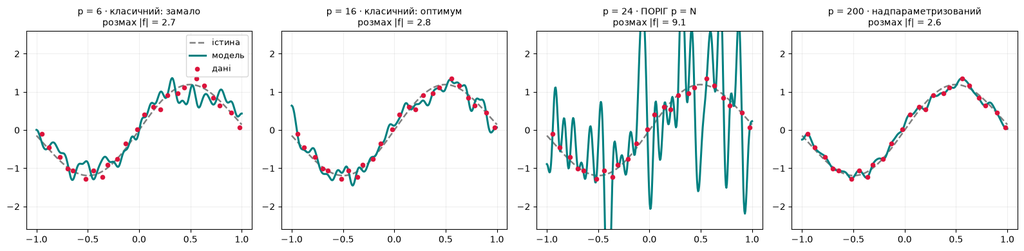

```
p=  6  розмах кривої =       2.7   ‖γ‖ =      1.50
p= 16  розмах кривої =       2.8   ‖γ‖ =      1.86
p= 24  розмах кривої =       9.1   ‖γ‖ =     18.01
p=200  розмах кривої =       2.6   ‖γ‖ =      0.42

При p = 24 крива теж проходить крізь усі точки — але між ними вилітає
далеко за межі малюнка: її розмах утричі більший за розмах істини.
При p = 200 вона проходить крізь ті самі точки, а між ними тримається біля істини.
Обидві «перенавчені» за класичним означенням. Поводяться протилежно.
```

```python
режими = [(6, "класичний: замало"), (16, "класичний: оптимум"),
          (24, "ПОРІГ p = N"), (200, "надпараметризований")]

# беремо не перший-ліпший жереб ознак, а типовий: той, у якого норма ваг
# на порозі дорівнює медіанній по всіх жеребах
норми_на_порозі = [np.linalg.norm(навчити(матриця_плану(ж, КІЛЬКІСТЬ_НАВЧАЛЬНИХ, базис_train), y_train))
                   for ж in range(КІЛЬКІСТЬ_ЖЕРЕБІВ)]
ТИПОВИЙ_ЖЕРЕБ = int(np.argsort(норми_на_порозі)[КІЛЬКІСТЬ_ЖЕРЕБІВ // 2])
print(f"типовий жереб ознак: №{ТИПОВИЙ_ЖЕРЕБ} (‖γ‖ на порозі = {норми_на_порозі[ТИПОВИЙ_ЖЕРЕБ]:.1f})\n")

fig, axes = plt.subplots(1, 4, figsize=(16, 4))
for вісь, (p, підпис) in zip(axes, режими):
    ваги = навчити(матриця_плану(ТИПОВИЙ_ЖЕРЕБ, p, базис_train), y_train)
    крива = базис_сітки @ (ЖЕРЕБИ[ТИПОВИЙ_ЖЕРЕБ][:, :p] @ ваги)
    розмах = крива.max() - крива.min()

    вісь.plot(сітка, істинна_функція(сітка), color="gray", ls="--", lw=1.8, label="істина")
    вісь.plot(сітка, крива, color="teal", lw=2.2, label="модель")
    вісь.scatter(x_train, y_train, s=20, color="crimson", zorder=3, label="дані")
    # межі фіксовані під істину — щоб було видно, наскільки модель з них вилітає
    вісь.set_ylim(-2.6, 2.6)
    вісь.set_title(f"p = {p} · {підпис}\nрозмах |f| = {розмах:.1f}", fontsize=10)
    вісь.grid(alpha=.2)
axes[0].legend(fontsize=9)
plt.tight_layout(); plt.show()

for p, підпис in режими:
    ваги = навчити(матриця_плану(ТИПОВИЙ_ЖЕРЕБ, p, базис_train), y_train)
    крива = базис_сітки @ (ЖЕРЕБИ[ТИПОВИЙ_ЖЕРЕБ][:, :p] @ ваги)
    print(f"p={p:3d}  розмах кривої = {крива.max() - крива.min():9.1f}   ‖γ‖ = {np.linalg.norm(ваги):9.2f}")

print("\nПри p = 24 крива теж проходить крізь усі точки — але між ними вилітає")
print("далеко за межі малюнка: її розмах утричі більший за розмах істини.")
print("При p = 200 вона проходить крізь ті самі точки, а між ними тримається біля істини.")
print("Обидві «перенавчені» за класичним означенням. Поводяться протилежно.")
```

## 7. Норма коефіцієнтів — прихована пружина

Розмову про «величезну норму» ми вже перевірили одним числом. Тепер побудуємо ‖γ‖ уздовж усієї осі складності й порівняємо форму з кривою помилки.

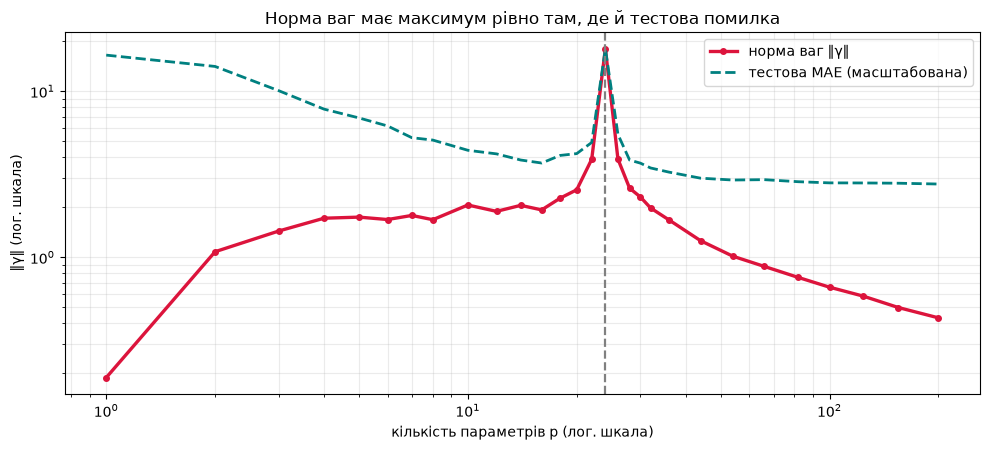

[output not shown]

```python
fig, ax = plt.subplots(figsize=(10, 4.6))

ax.plot(СІТКА_P, норма_ваг, color="crimson", lw=2.4, marker="o", ms=4, label="норма ваг ‖γ‖")
ax.plot(СІТКА_P, тест_mae * норма_ваг.max() / тест_mae.max(), color="teal", lw=2,
        ls="--", label="тестова MAE (масштабована)")
ax.axvline(КІЛЬКІСТЬ_НАВЧАЛЬНИХ, color="gray", ls="--", lw=1.6)
ax.set_xscale("log"); ax.set_yscale("log")
ax.set_xlabel("кількість параметрів p (лог. шкала)")
ax.set_ylabel("‖γ‖ (лог. шкала)")
ax.set_title("Норма ваг має максимум рівно там, де й тестова помилка")
ax.legend(); ax.grid(alpha=.25, which="both")
plt.tight_layout(); plt.show()

print(f"максимум норми стоїть на p = {СІТКА_P[int(np.argmax(норма_ваг))]}")
print(f"‖γ‖ на порозі = {норма_ваг[індекс_порогу]:.1f}, при p = 200 = {норма_ваг[-1]:.2f}")

assert СІТКА_P[int(np.argmax(норма_ваг))] == КІЛЬКІСТЬ_НАВЧАЛЬНИХ
print("\n✅ норма ваг вибухає рівно на порозі — дві криві мають один і той самий рельєф")
```

## 8. Явний штраф прибирає пік

Якщо пік спричинений гігантською нормою, то штраф за норму має його зрізати. Додаємо у функцію втрат звичайний L2-доданок (гребенева регресія):

L(γ) = ‖y − Φγ‖² + λ·‖γ‖²

Тепер ми не вимагаємо точної інтерполяції — торгуємось між точністю на навчальних даних і величиною ваг.

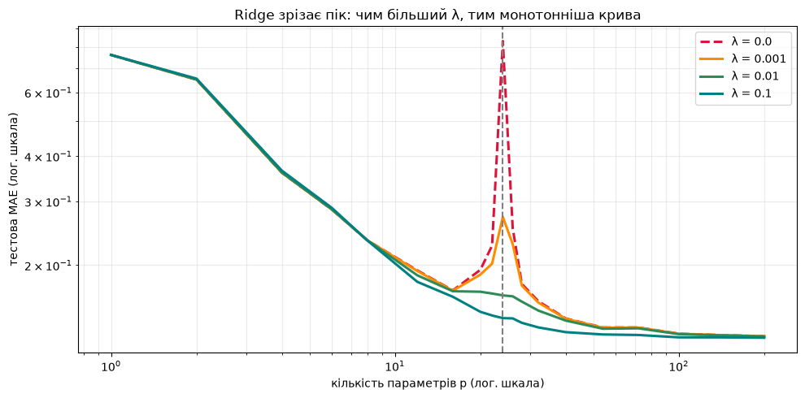

```
       λ    помилка на порозі    найкраще на кривій
     0.0               0.8311                0.1273
   0.001               0.2719                0.1273
    0.01               0.1650                0.1272
     0.1               0.1428                0.1261

✅ штраф λ = 0.1 зменшив пік з 0.831 до 0.143
Найкраще значення регуляризованої моделі майже дорівнює тому, чого
надпараметризована модель досягала взагалі без штрафу. Мінімальна норма —
це і є прихована («неявна») регуляризація.
```

```python
СІТКА_P2 = [1, 2, 4, 6, 8, 12, 16, 20, 22, 24, 26, 28, 32, 40, 54, 72, 100, 140, 200]
індекс_порогу2 = СІТКА_P2.index(КІЛЬКІСТЬ_НАВЧАЛЬНИХ)

fig, ax = plt.subplots(figsize=(10, 5))
кольори = ["crimson", "darkorange", "seagreen", "teal"]
результати = {}

for колір, штраф in zip(кольори, [0.0, 0.001, 0.01, 0.1]):
    крива, _, _ = побудувати_криву(СІТКА_P2, штраф=штраф)
    результати[штраф] = крива
    стиль = "--" if штраф == 0 else "-"
    ax.plot(СІТКА_P2, крива, color=колір, lw=2.2, ls=стиль, label=f"λ = {штраф}")

ax.axvline(КІЛЬКІСТЬ_НАВЧАЛЬНИХ, color="gray", ls="--", lw=1.5)
ax.set_xscale("log"); ax.set_yscale("log")
ax.set_xlabel("кількість параметрів p (лог. шкала)"); ax.set_ylabel("тестова MAE (лог. шкала)")
ax.set_title("Ridge зрізає пік: чим більший λ, тим монотонніша крива")
ax.legend(); ax.grid(alpha=.25, which="both")
plt.tight_layout(); plt.show()

print(f"{'λ':>8} {'помилка на порозі':>20} {'найкраще на кривій':>21}")
for штраф, крива in результати.items():
    print(f"{штраф:>8} {крива[індекс_порогу2]:20.4f} {крива.min():21.4f}")

пік_без_штрафу = результати[0.0][індекс_порогу2]
пік_зі_штрафом = результати[0.1][індекс_порогу2]
assert пік_зі_штрафом < пік_без_штрафу / 3, "штраф мав зрізати пік щонайменше втричі!"
print(f"\n✅ штраф λ = 0.1 зменшив пік з {пік_без_штрафу:.3f} до {пік_зі_штрафом:.3f}")
print("Найкраще значення регуляризованої моделі майже дорівнює тому, чого")
print("надпараметризована модель досягала взагалі без штрафу. Мінімальна норма —")
print("це і є прихована («неявна») регуляризація.")
```

## 9. Чи винен у піку шум

Природна гіпотеза: пік виникає тому, що на порозі модель змушена точно відтворити шум. Перевіримо її прямо — покрутимо рівень шуму від нуля до великого.

```python
print(f"{'σ':>6} {'пік (p=N)':>12} {'класичний мін.':>16} {'дно 2-го спуску':>17} {'виграш 2-ї гілки':>18}")
рядки = []
for σ in [0.0, 0.06, 0.12, 0.30]:
    крива, _, _ = побудувати_криву(СІТКА_P2, рівень_шуму=σ)
    пік = крива[індекс_порогу2]
    класика = крива[np.array(СІТКА_P2) <= КІЛЬКІСТЬ_НАВЧАЛЬНИХ - 4].min()
    дно = крива[np.array(СІТКА_P2) >= 2 * КІЛЬКІСТЬ_НАВЧАЛЬНИХ].min()
    рядки.append((σ, пік, класика, дно))
    print(f"{σ:>6} {пік:12.4f} {класика:16.4f} {дно:17.4f} {класика / дно:17.2f}×")

σ_нуль, пік_без_шуму, класика_без_шуму, _ = рядки[0]
assert пік_без_шуму > 2 * класика_без_шуму, "без шуму пік мав би лишитись!"
print("\n✅ при σ = 0 пік нікуди не зник — жорсткість на порозі шуму не потребує")
print("Зате виграш другої гілки шум зʼїдає: без шуму вона у 8 разів краща за класику,")
print("а при σ = 0.30 перевага майже зникає. Інтерполювати брудні мітки сенсу мало.")
```

```
     σ    пік (p=N)   класичний мін.   дно 2-го спуску   виграш 2-ї гілки
```

```
   0.0       0.3729           0.1223            0.0148              8.25×
```

```
  0.06       0.6310           0.1307            0.0651              2.01×
```

```
  0.12       0.8311           0.1703            0.1273              1.34×
```

```
   0.3       1.4189           0.3431            0.3171              1.08×

✅ при σ = 0 пік нікуди не зник — жорсткість на порозі шуму не потребує
Зате виграш другої гілки шум зʼїдає: без шуму вона у 8 разів краща за класику,
а при σ = 0.30 перевага майже зникає. Інтерполювати брудні мітки сенсу мало.
```

## 💻 Завдання

### 🟢 Рівень 1 — разом

1. Зменш `КІЛЬКІСТЬ_ТЕСТОВИХ` до 20 і перебудуй головну криву. Куди поїхав пік? Це і є причина, чому тестова вибірка має бути великою.
2. Зміни `КІЛЬКІСТЬ_НАВЧАЛЬНИХ` на 40 і перевір, що пік переїхав на p = 40.

### 🟡 Рівень 2 — самостійно

1. Зміни `СПАД_АМПЛІТУДИ` з 1.2 на 0.3 — ознаки стануть різкішими. Що сталося з висотою піку й з дном другого спуску? Поясни через гладкість.
2. Побудуй криву не для медіани, а для кожного жеребу окремо (15 тонких ліній). Де розкид між жеребами найбільший і чому саме там?

### 🔴 Рівень 3 — виклик

1. Побудуй ту саму картинку для повноцінної нейромережі: `MLPRegressor` зі зростаючою шириною прихованого шару. Чи видно пік? Чому його важче спіймати?
2. Відтвори **epoch-wise double descent**: зафіксуй p = 24 і будуй тестову помилку як функцію кількості кроків градієнтного спуску, а не кількості параметрів.

## 🧪 Самоперевірка

**1. Чому `np.linalg.pinv` працює і при p < N, і при p > N?**

**відповідь**

Псевдообернена матриця за означенням дає розвʼязок з найменшою нормою серед усіх, що мінімізують ‖Φγ − y‖. При p < N мінімум єдиний — це МНК. При p > N мінімум досягається на цілій множині (усі інтерполянти), і pinv обирає з неї найкоротший вектор.

**2. Модель має 24 параметри й 24 навчальні точки. Чи можна врятувати ситуацію, не міняючи розмір моделі?**

**відповідь**

Так — додати регуляризацію. Розділ 8 показує це числом: λ = 0.1 зрізає пік у шість разів. Пік виникає не від кількості параметрів, а від того, що єдиний інтерполюючий розвʼязок вимагає гігантської норми. Штраф просто забороняє таку норму.

**3. Чому пік не зникає при нульовому шумі?**

**відповідь**

Бо він викликаний не шумом, а **жорсткістю**: при p = N інтерполюючий розвʼязок рівно один, і ніхто не гарантував, що він гладкий. Випадкові ознаки майже напевно дають майже пропорційну пару, і щоб вона склалась у потрібні значення, коефіцієнти мусять бути велетенськими й протилежними за знаком.